# Pima Indians Diabetes Database.

## TC1002S.100

## Herramientas computacionales: el arte de la analítica (Gpo 100).

Emiliano Vivas Rodríguez ( a01424732@tec.mx ).

### Introducción.

Este conjunto de datos proviene originalmente del Instituto Nacional de Diabetes y Enfermedades Digestivas y Renales. El objetivo es predecir en base a medidas diagnósticas si un paciente tiene diabetes.

Se impusieron varias restricciones a la selección de estas instancias de una base de datos más grande. En particular, todos los pacientes aquí son mujeres de, al menos, 21 años de herencia indígena pima. Se cuentan con 768 registros en la base de datos.

- Pregnancies: número de embarazos obtenidos.
- PG Concentration: concentración de glucosa en plasma a las 2 horas en una prueba de tolerancia oral a la glucosa.
- Diastolic BP: presión arterial diastólica (mm Hg).
- Tri Fold Thick: grosor del pliegue cutáneo del tríceps (mm).
- Serum Ins: insulina sérica de 2 horas (mu U/ml).
- BMI: índice de masa corporal (peso en kg/(altura en m)^2).
- DP Function: función de pedigrí de diabetes.
- Age: edad (años).
- Diabetes: variable de clase (0 o 1).

### Recolección de datos.

La recolección de los datos fue la parte más tediosa de este proceso debido a que no se encuentra gran cantidad de bases de datos de dominio público en la web, por lo que la investigación fue exhaustiva. Después de la búsqueda, se logró obtener una base de datos del Instituto Nacional de Diabetes y Enfermedades Digestivas y Renales quienes registraron propiedades físicas de mujeres con herencia indígena pima y provenientes de Arizona en los Estados Unidos de América.

### Identificación, categorización y limpieza de los datos.

La base de datos se encontraba, desde un comienzo, limpia ya que no se encontraban registros nulos o problemas de duplicidad con las observaciones. Por otro lado, se aplicaron diversos filtros para comprobar si una persona se encontraba enferma de diabetes o no, con el fin de observar posibles factores de los cual podamos utilizar para realizar nuestro análisis con las herramientas computacionales a nuestro alcance. Además, se analizó cada una de las variables participantes en el estudio y se realizó un análisis estadístico descriptivo, cuyos resultados develaron que se presentan diversas observaciones excepcionales que cumplen con las características de registros atípicos y extremos, en algunos casos.

### Exploración y análisis de los datos.

Al concluir la limpieza y la categorización, se emplearon gráficas y diagramas de cada campo de la base de datos para comparar a la población sana con la enferma y, de esta manera, identificar patrones que resultaran diferentes entre ambas poblaciones y, además, generar hipótesis que puedan ayudar a solucionar nuestra problemática inicial, la identificación de factores determinantes de diabetes para mujeres existentes dentro de la muestra poblacional de estudio. Entre las gráficas utilizadas, se realizaron graficas de dispersión, gráficas de barras y gráficas de pastel; las cuales nos ayudaron a identificar las relaciones que pudiesen haber entre los valores de nuestro estudio. Asimismo, se produjo una tabla de correlación para ayudarnos a observar estos datos de manera organizada e interpretar si se encuentran relaciones que no sean visibles a simple vista. Por último, se aplicó Machine Learning, con el algoritmo de máquinas de vectores de soporte, para predecir si un sujeto de la muestra presenta diabetes o se encuentra sano de acuerdo con sus datos registrados.

### Anexo. Script Python y gráficas generadas.

```python
import pandas as pd
import matplotlib.pyplot as plt
import seaborn as sns
from statistics import mode
import matplotlib.pyplot as plt
from sklearn.metrics import plot_confusion_matrix
from sklearn.model_selection import train_test_split
from sklearn.svm import SVC
from sklearn.preprocessing import RobustScaler
from sklearn.metrics import classification_report, confusion_matrix
from sklearn.model_selection import train_test_split
from sklearn.linear_model import LogisticRegression
from sklearn.neighbors import KNeighborsClassifier
from sklearn.svm import SVC
from sklearn.tree import DecisionTreeClassifier
from sklearn.ensemble import RandomForestClassifier, AdaBoostClassifier
import time
tabla = pd.read_excel("Diabetes.xlsx")
tablaHealthy = tabla.groupby("Diabetes").get_group("Healthy")
tablaSick = tabla.groupby("Diabetes").get_group("Sick")
PREHealthy = tablaHealthy["Pregnancies"]
PRESick = tablaSick["Pregnancies"]
print("Pregnancies")
print("El valor minimo obtenido de la tabla Pregnancies para una persona sana es: %s"% PREHealthy.min())
print("El valor maximo obtenido de la tabla Pregnancies para una persona sana es: %s \n"% PREHealthy.max())
print("El valor minimo obtenido de la tabla Pregnancies para una persona enferma es: %s"% PRESick.min())
print("El valor maximo obtenido de la tabla Pregnancies para una persona enferma es: %s \n"% PRESick.max())
print("El valor de la media del valor Pregnancies para una persona sana es: ", PREHealthy.mean())
print("El valor de la media del valor Pregnancies para una persona enferma es: %0.3f \n" % PRESick.mean())
print("El valor de la moda del valor Pregnancies para una persona sana es: %s"% mode(PREHealthy))
print("El valor de la moda del valor Pregnancies para una persona enferma es: %s \n\n"% mode(PRESick))
PGHealthy = tablaHealthy["PG Concentration"]
PGSick = tablaSick["PG Concentration"]
print("PG Concentration")
print("El valor minimo obtenido de la tabla PG Concentration para una persona sana es: %s"% PGHealthy.min())
print("El valor maximo obtenido de la tabla PG Concentration para una persona sana es: %s \n"% PGHealthy.max())
print("El valor minimo obtenido de la tabla PG Concentration para una persona enferma es: %s"% PGSick.min())
print("El valor maximo obtenido de la tabla PG Concentration para una persona enferma es: %s \n"% PGSick.max())
print("El valor de la media del valor PG Concentration para una persona sana es: ", PGHealthy.mean())
print("El valor de la media del valor PG Concentration para una persona enferma es: %0.3f \n" % PGSick.mean())
print("El valor de la moda del valor PG Concentration para una persona sana es: %s"% mode(PGHealthy))
print("El valor de la moda del valor PG Concentration para una persona enferma es: %s \n\n"% mode(PGSick))
BPHealthy = tablaHealthy["Diastolic BP"]
BPSick = tablaSick["Diastolic BP"]
print("Diastolic BP")
print("El valor minimo obtenido de la tabla Diastolic BP para una persona sana es: %s"% BPHealthy.min())
print("El valor maximo obtenido de la tabla Diastolic BP para una persona sana es: %s \n"% BPHealthy.max())
print("El valor minimo obtenido de la tabla Diastolic BP para una persona enferma es: %s"% BPSick.min())
print("El valor maximo obtenido de la tabla Diastolic BP para una persona enferma es: %s \n"% BPSick.max())
print("El valor de la media del valor Diastolic BP para una persona sana es: ", BPHealthy.mean())
print("El valor de la media del valor Diastolic BP para una persona enferma es: %0.3f \n" % BPSick.mean())
print("El valor de la moda del valor Diastolic BP para una persona sana es: %s"% mode(BPHealthy))
print("El valor de la moda del valor Diastolic BP para una persona enferma es: %s \n\n"% mode(BPSick))
TFTHealthy = tablaHealthy["Tri Fold Thick"]
TFTSick = tablaSick["Tri Fold Thick"]
print("Tri Fold Thick")
print("El valor minimo obtenido de la tabla Tri Fold Thick para una persona sana es: %s"% TFTHealthy.min())
print("El valor maximo obtenido de la tabla Tri Fold Thick para una persona sana es: %s \n"% TFTHealthy.max())
print("El valor minimo obtenido de la tabla Tri Fold Thick para una persona enferma es: %s"% TFTSick.min())
print("El valor maximo obtenido de la tabla Tri Fold Thick para una persona enferma es: %s \n"% TFTSick.max())
print("El valor de la media del valor Tri Fold Thick para una persona sana es: ", TFTHealthy.mean())
print("El valor de la media del valor Tri Fold Thick para una persona enferma es: %0.3f \n" % TFTSick.mean())
print("El valor de la moda del valor Tri Fold Thick para una persona sana es: %s"% mode(TFTHealthy))
print("El valor de la moda del valor Tri Fold Thick para una persona enferma es: %s \n\n"% mode(TFTSick))
SIHealthy = tablaHealthy["Serum Ins"]
SISick = tablaSick["Serum Ins"]
print("Serum Ins")
print("El valor minimo obtenido de la tabla Serum Ins para una persona sana es: %s"% SIHealthy.min())
print("El valor maximo obtenido de la tabla Serum Ins para una persona sana es: %s \n"% SIHealthy.max())
print("El valor minimo obtenido de la tabla Serum Ins para una persona enferma es: %s"% SISick.min())
print("El valor maximo obtenido de la tabla Serum Ins para una persona enferma es: %s \n"% SISick.max())
print("El valor de la media del valor Serum Ins para una persona sana es: ", SIHealthy.mean())
print("El valor de la media del valor Serum Ins para una persona enferma es: %0.3f \n" % SISick.mean())
print("El valor de la moda del valor Serum Ins para una persona sana es: %s"% mode(SIHealthy))
print("El valor de la moda del valor Serum Ins para una persona enferma es: %s \n\n"% mode(SISick))
BMIHealthy = tablaHealthy["BMI"]
BMISick = tablaSick["BMI"]
print("Serum Ins")
print("El valor minimo obtenido de la tabla Serum Ins para una persona sana es: %.0f"% BMIHealthy.min())
print("El valor maximo obtenido de la tabla Serum Ins para una persona sana es: %.1f \n"% BMIHealthy.max())
print("El valor minimo obtenido de la tabla Serum Ins para una persona enferma es: %.0f"% BMISick.min())
print("El valor maximo obtenido de la tabla Serum Ins para una persona enferma es: %.1f \n"% BMISick.max())
print("El valor de la media del valor Serum Ins para una persona sana es: ", BMIHealthy.mean())
print("El valor de la media del valor Serum Ins para una persona enferma es: %0.3f \n" % BMISick.mean())
print("El valor de la moda del valor Serum Ins para una persona sana es: %.0f"% mode(BMIHealthy))
print("El valor de la moda del valor Serum Ins para una persona enferma es: %.1f \n\n"% mode(BMISick))
DPHealthy = tablaHealthy["DP Function"]
DPSick = tablaSick["DP Function"]
print("DP Function")
print("El valor minimo obtenido de la tabla DP Function para una persona sana es: %.3f"% DPHealthy.min())
print("El valor maximo obtenido de la tabla DP Function para una persona sana es: %.3f \n"% DPHealthy.max())
print("El valor minimo obtenido de la tabla DP Function para una persona enferma es: %.3f"% DPSick.min())
print("El valor maximo obtenido de la tabla DP Function para una persona enferma es: %.3f \n"% DPSick.max())
print("El valor de la media del valor DP Function para una persona sana es: %0.4f"% DPHealthy.mean())
print("El valor de la media del valor DP Function para una persona enferma es: %0.4f \n" % DPSick.mean())
print("El valor de la moda del valor DP Function para una persona sana es: %.3f"% mode(DPHealthy))
print("El valor de la moda del valor DP Function para una persona enferma es: %.3f \n\n"% mode(DPSick))
AGEHealthy = tablaHealthy["Age"]
AGESick = tablaSick["Age"]
print("Edad")
print("El valor minimo obtenido de la edad para una persona sana es: %s"% AGEHealthy.min())
print("El valor maximo obtenido de la edad para una persona sana es: %s \n"% AGEHealthy.max())
print("El valor minimo obtenido de la edad para una persona enferma es: %s"% AGESick.min())
print("El valor maximo obtenido de la edad para una persona enferma es: %s \n"% AGESick.max())
print("El valor de la media de la edad para una persona sana es: %0.3f"% AGEHealthy.mean())
print("El valor de la media de la edad para una persona enferma es: %0.3f \n" % AGESick.mean())
print("El valor de la moda de la edad para una persona sana es: %s"% mode(AGEHealthy))
print("El valor de la moda de la edad para una persona enferma es: %s \n\n"% mode(AGESick))
print("Enfermos - Sanos")
print("El numero de personas sanas es de: ", len(tablaHealthy))
print("El numero de personas enfermas es de: ", len(tablaSick), end='\n')
plt.subplot(331)
plt.pie([len(tablaHealthy),len(tablaSick)],labels=["Healthy","Sick"],autopct = "%0.0f%%")
plt.subplot(332)
plt.hist(tablaHealthy["Pregnancies"], bins = 20, ec="black")
plt.hist(tablaSick["Pregnancies"], bins = 20, ec="black")
plt.title("Pregnancies")
plt.ylabel("Frequency")
plt.subplot(333)
plt.hist(tablaHealthy["PG Concentration"], bins = 20, ec="black")
plt.hist(tablaSick["PG Concentration"], bins = 20,ec="black")
plt.title("PG Concentration")
plt.ylabel("Frequency")
plt.subplot(334)
plt.hist(tablaHealthy["Diastolic BP"], bins = 20, ec="black")
plt.hist(tablaSick["Diastolic BP"], bins = 20, ec="black")
plt.title("Diastolic BP")
plt.ylabel("Frequency")
plt.subplot(335)
plt.hist(tablaHealthy["Tri Fold Thick"], bins = 20, ec="black")
plt.hist(tablaSick["Tri Fold Thick"], bins = 20, ec="black")
plt.title("Tri Fold Thick")
plt.ylabel("Frequency")
plt.subplot(336)
plt.hist(tablaHealthy["Serum Ins"], bins = 20, ec="black")
plt.hist(tablaSick["Serum Ins"], bins = 20, ec="black")
plt.title("Serum Ins")
plt.ylabel("Frequency")
plt.subplot(337)
plt.hist(tablaHealthy["BMI"], bins = 20, ec="black")
plt.hist(tablaSick["BMI"], bins = 20, ec="black")
plt.title("BMI")
plt.ylabel("Frequency")
plt.subplot(338)
plt.hist(tablaHealthy["DP Function"], bins = 20, ec="black")
plt.hist(tablaSick["DP Function"], bins = 20, ec="black")
plt.title("DP Function")
plt.ylabel("Frequency")
plt.subplot(339)
plt.hist(tablaHealthy["Age"], bins = 20, ec="black")
plt.hist(tablaSick["Age"], bins = 20, ec="black")
plt.title("Age")
plt.ylabel("Frequency")
plt.show()
fig, axs = plt.subplots(3, 3)
axs[0, 0].boxplot([PREHealthy, PRESick], 1)
axs[0, 0].set_title('Pregnancies')
axs[0, 1].boxplot([PGHealthy, PGSick], 1)
axs[0, 1].set_title('PG Concentration')
axs[0, 2].boxplot([BPHealthy, BPSick], 1)
axs[0, 2].set_title('Diastolic BP')
axs[1, 0].boxplot([TFTHealthy, TFTSick], 1)
axs[1, 0].set_title('Tri Fold Thick')
axs[1, 1].boxplot([SIHealthy, SISick], 1)
axs[1, 1].set_title('Serum Ins')
axs[1, 2].boxplot([BMIHealthy, BMISick], 1)
axs[1, 2].set_title('BMI')
axs[2, 0].boxplot([DPHealthy, DPSick], 1)
axs[2, 0].set_title('DP Function')
axs[2, 1].boxplot([AGEHealthy, AGESick], 1)
axs[2, 1].set_title('Age')
axs[2, 2].boxplot([PREHealthy, PRESick], 1)
axs[2, 2].set_title("Pregnancies")
plt.show()
sickPopulation = {"Pregnancies":PRESick, "PG Concentration":PGSick, 'Diastolic BP':BPSick, 'Tri Fold Thick':TFTSick, 'Serum Ins':SISick, 'BMI':BMISick, 'DP Function':DPSick, 'Age':AGESick}
diabetes_df = pd.DataFrame(sickPopulation)
print(diabetes_df)
corr_df = diabetes_df.corr(method='pearson')
print("The correlation DataFrame is:")
print(corr_df, "\n")
sns.heatmap(corr_df, annot=True)
plt.show()
plt.scatter(sickPopulation["Pregnancies"], sickPopulation["Age"])
plt.xlabel("Pregnancies")
plt.ylabel("Age")
plt.title("Pregnancies vs. Age")
plt.show()
plt.scatter(sickPopulation["BMI"], sickPopulation["Tri Fold Thick"])
plt.xlabel("BMI")
plt.ylabel("Tri Fold Thick")
plt.title("BMI vs. Tri Fold Thick")
plt.show()
plt.scatter(sickPopulation["Serum Ins"], sickPopulation["Tri Fold Thick"])
plt.xlabel("Serum Ins")
plt.ylabel("Tri Fold Thick")
plt.title("Serum Ins vs. Tri Fold Thick")
plt.show()
plt.scatter(sickPopulation["Serum Ins"], sickPopulation["PG Concentration"])
plt.xlabel("Serum Ins")
plt.ylabel("PG Concentration")
plt.title("Serum Ins vs. PG Concentration")
plt.show()
plt.scatter(sickPopulation["Diastolic BP"], sickPopulation["Tri Fold Thick"])
plt.xlabel("Diastolic BP")
plt.ylabel("Tri Fold Thick")
plt.title("Diastolic BP vs. Tri Fold Thick")
plt.show()
plt.scatter(sickPopulation["Diastolic BP"], sickPopulation["Age"])
```

```
Pregnancies
El valor minimo obtenido de la tabla Pregnancies para una persona sana es: 0
El valor maximo obtenido de la tabla Pregnancies para una persona sana es: 13

El valor minimo obtenido de la tabla Pregnancies para una persona enferma es: 0
El valor maximo obtenido de la tabla Pregnancies para una persona enferma es: 17

El valor de la media del valor Pregnancies para una persona sana es:  3.298
El valor de la media del valor Pregnancies para una persona enferma es: 4.866

El valor de la moda del valor Pregnancies para una persona sana es: 1
El valor de la moda del valor Pregnancies para una persona enferma es: 0


PG Concentration
El valor minimo obtenido de la tabla PG Concentration para una persona sana es: 0
El valor maximo obtenido de la tabla PG Concentration para una persona sana es: 197

El valor minimo obtenido de la tabla PG Concentration para una persona enferma es: 0
El valor maximo obtenido de la tabla PG Concentration para una persona enferma es: 199

El valor de la media del valor PG Concentration para una persona sana es:  109.98
El valor de la media del valor PG Concentration para una persona enferma es: 141.257

El valor de la moda del valor PG Concentration para una persona sana es: 99
El valor de la moda del valor PG Concentration para una persona enferma es: 125


Diastolic BP
El valor minimo obtenido de la tabla Diastolic BP para una persona sana es: 0
El valor maximo obtenido de la tabla Diastolic BP para una persona sana es: 122

El valor minimo obtenido de la tabla Diastolic BP para una persona enferma es: 0
El valor maximo obtenido de la tabla Diastolic BP para una persona enferma es: 114

El valor de la media del valor Diastolic BP para una persona sana es:  68.184
El valor de la media del valor Diastolic BP para una persona enferma es: 70.825

El valor de la moda del valor Diastolic BP para una persona sana es: 74
El valor de la moda del valor Diastolic BP para una persona enferma es: 70
```

[output cut: 60 more lines]

```
El valor maximo obtenido de la edad para una persona sana es: 81

El valor minimo obtenido de la edad para una persona enferma es: 21
El valor maximo obtenido de la edad para una persona enferma es: 70

El valor de la media de la edad para una persona sana es: 31.190
El valor de la media de la edad para una persona enferma es: 37.067

El valor de la moda de la edad para una persona sana es: 22
El valor de la moda de la edad para una persona enferma es: 25


Enfermos - Sanos
El numero de personas sanas es de:  500
El numero de personas enfermas es de:  268
```

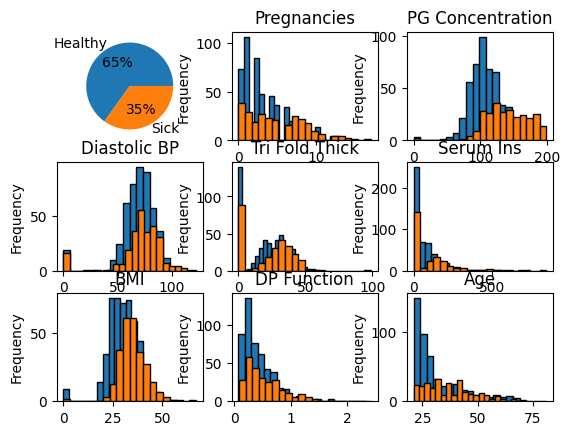

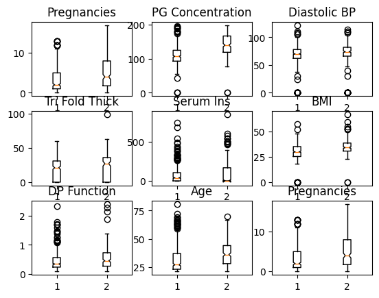

```
     Pregnancies  PG Concentration  Diastolic BP  Tri Fold Thick  Serum Ins  \
0              6               148            72              35          0
2              8               183            64               0          0
4              0               137            40              35        168
6              3                78            50              32         88
8              2               197            70              45        543
..           ...               ...           ...             ...        ...
755            1               128            88              39        110
757            0               123            72               0          0
759            6               190            92               0          0
761            9               170            74              31          0
766            1               126            60               0          0

      BMI  DP Function  Age
0    33.6        0.627   50
2    23.3        0.672   32
4    43.1        2.288   33
6    31.0        0.248   26
8    30.5        0.158   53
..    ...          ...  ...
755  36.5        1.057   37
757  36.3        0.258   52
759  35.5        0.278   66
761  44.0        0.403   43
766  30.1        0.349   47

[268 rows x 8 columns]
The correlation DataFrame is:
                  Pregnancies  PG Concentration  Diastolic BP  Tri Fold Thick  \
Pregnancies          1.000000         -0.054591      0.126963       -0.079165
PG Concentration    -0.054591          1.000000      0.068699        0.037618
Diastolic BP         0.126963          0.068699      1.000000        0.225247
Tri Fold Thick      -0.079165          0.037618      0.225247        1.000000
Serum Ins           -0.078563          0.261368      0.089367        0.456558
BMI                 -0.159071          0.050418      0.133951        0.312058
DP Function         -0.069195          0.026474      0.034522        0.273900
Age                  0.444987          0.098565      0.262684       -0.092012

                  Serum Ins       BMI  DP Function       Age
Pregnancies       -0.078563 -0.159071    -0.069195  0.444987
PG Concentration   0.261368  0.050418     0.026474  0.098565
Diastolic BP       0.089367  0.133951     0.034522  0.262684
Tri Fold Thick     0.456558  0.312058     0.273900 -0.092012
Serum Ins          1.000000  0.055112     0.101565  0.023944
BMI                0.055112  1.000000     0.136761 -0.188012
DP Function        0.101565  0.136761     1.000000 -0.088119
Age                0.023944 -0.188012    -0.088119  1.000000
```

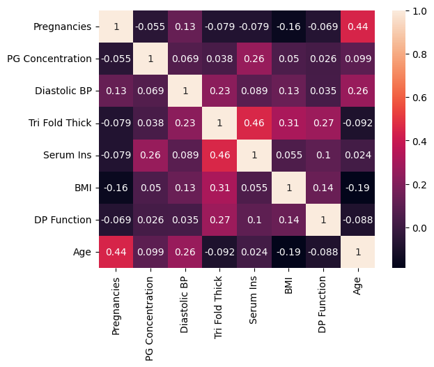

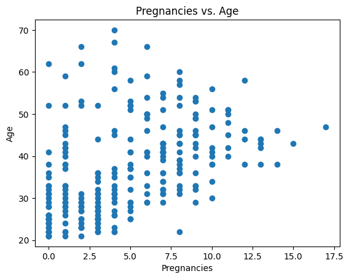

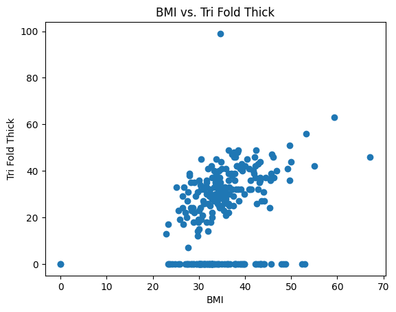

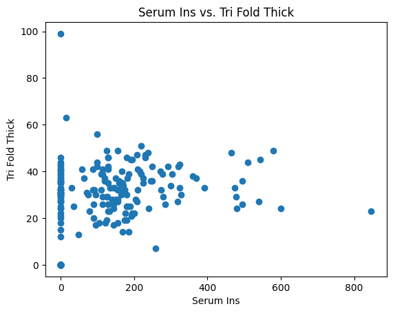

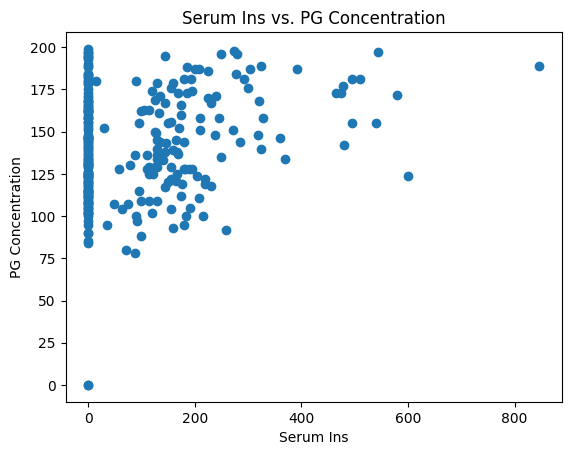

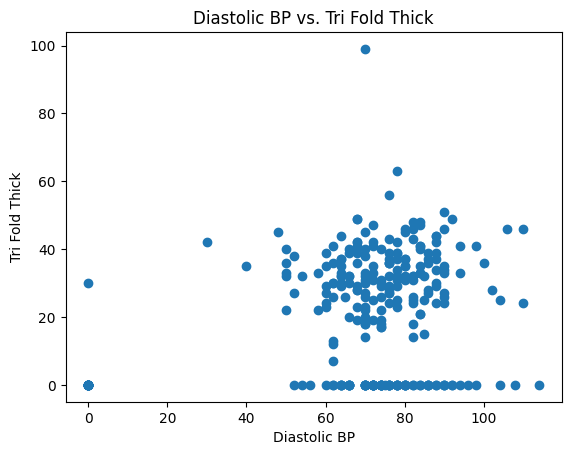

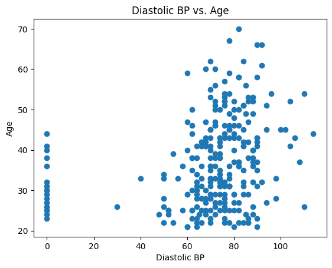

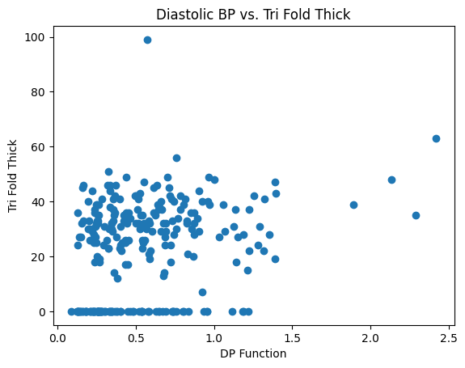

```
Diabetes
0    500
1    268
Name: Diabetes, dtype: int64
Regresión logística
0.003989219665527344
              precision    recall  f1-score   support

           0       0.85      0.78      0.81       143
           1       0.68      0.78      0.73        88

    accuracy                           0.78       231
   macro avg       0.77      0.78      0.77       231
weighted avg       0.79      0.78      0.78       231

Máquinas de vectores de soporte
0.01296377182006836
              precision    recall  f1-score   support

           0       0.81      0.90      0.85       143
           1       0.81      0.66      0.73        88

    accuracy                           0.81       231
   macro avg       0.81      0.78      0.79       231
weighted avg       0.81      0.81      0.81       231

[[129  14]
 [ 30  58]]
```

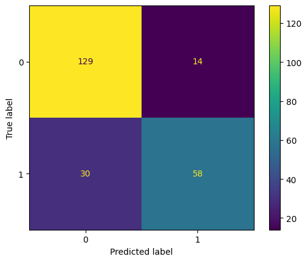

```
0.022937774658203125
              precision    recall  f1-score   support

           0       0.73      0.94      0.82       143
           1       0.81      0.44      0.57        88

    accuracy                           0.75       231
   macro avg       0.77      0.69      0.70       231
weighted avg       0.76      0.75      0.73       231

0.012961864471435547
              precision    recall  f1-score   support

           0       0.79      0.88      0.83       143
           1       0.76      0.62      0.69        88

    accuracy                           0.78       231
   macro avg       0.78      0.75      0.76       231
weighted avg       0.78      0.78      0.78       231

0.016981840133666992
              precision    recall  f1-score   support

           0       0.75      0.86      0.80       143
           1       0.70      0.53      0.61        88

    accuracy                           0.74       231
   macro avg       0.73      0.70      0.70       231
weighted avg       0.73      0.74      0.73       231

K Vecinos más cercanos
0.001993417739868164
Training Score:  0.8081936685288641
Testing Score:  0.7532467532467533
              precision    recall  f1-score   support

           0       0.79      0.83      0.81       143
           1       0.69      0.64      0.66        88

    accuracy                           0.75       231
```

[output cut: 39 more lines]

```

0.33911848068237305
Adaptive Boosting
Training Score:  0.8770949720670391
Testing Score:  0.7142857142857143
              precision    recall  f1-score   support

           0       0.75      0.80      0.78       143
           1       0.64      0.58      0.61        88

    accuracy                           0.71       231
   macro avg       0.70      0.69      0.69       231
weighted avg       0.71      0.71      0.71       231

0.3859412670135498
```

```python
plt.xlabel("Diastolic BP")
plt.ylabel("Age")
plt.title("Diastolic BP vs. Age")
plt.show()
plt.scatter(sickPopulation["DP Function"], sickPopulation["Tri Fold Thick"])
plt.xlabel("DP Function")
plt.ylabel("Tri Fold Thick")
plt.title("Diastolic BP vs. Tri Fold Thick")
plt.show()
labels = {'Healthy' :0, 'Sick': 1}
tabla.replace({'Diabetes':labels}, inplace = True)
df2 = tabla.groupby(['Diabetes'])['Diabetes'].count()
print(df2)
X = tabla.drop('Diabetes', axis = 1).values
y = tabla['Diabetes'].values
X_train, X_test, y_train, y_test = train_test_split(X, y, test_size = 0.3, random_state = 123)
robust = RobustScaler()
X_train = robust.fit_transform(X_train)
X_test = robust.transform(X_test)
start = time.time()
#Logistic Regression
print("Regresión logística", end='\n')
lr = LogisticRegression(class_weight='balanced')
lr.fit(X_train, y_train)
end = time.time()
print(end - start)
y_pred = lr.predict(X_test)
reporte = classification_report(y_test, y_pred)
print(reporte)
CF = confusion_matrix(y_test, y_pred)
df_cf = pd.DataFrame(CF)
df_cf.style.background_gradient()
#Support vector machine
print("Máquinas de vectores de soporte", end='\n')
start = time.time()
svc = SVC(kernel='linear')
svc.fit(X_train, y_train)
end = time.time()
print(end - start)
y_pred = svc.predict(X_test)
reporte = classification_report(y_test, y_pred)
print(reporte)
CF = confusion_matrix(y_test, y_pred)
print(CF)
plot_confusion_matrix(svc, X_test, y_test)
plt.show()
print("\n\n\n")
df_cf = pd.DataFrame(CF)
df_cf.style.background_gradient()
start = time.time()
svc = SVC(kernel='poly')
svc.fit(X_train, y_train)
end = time.time()
print(end - start)
y_pred = svc.predict(X_test)
reporte = classification_report(y_test, y_pred)
print(reporte)
CF = confusion_matrix(y_test, y_pred)
df_cf = pd.DataFrame(CF)
df_cf.style.background_gradient()
start = time.time()
svc = SVC(kernel='rbf')
svc.fit(X_train, y_train)
end = time.time()
print(end - start)
y_pred = svc.predict(X_test)
reporte = classification_report(y_test, y_pred)
print(reporte)
CF = confusion_matrix(y_test, y_pred)
df_cf = pd.DataFrame(CF)
df_cf.style.background_gradient()
start = time.time()
svc = SVC(kernel='sigmoid')
svc.fit(X_train, y_train)
end = time.time()
print(end - start)
y_pred = svc.predict(X_test)
reporte = classification_report(y_test, y_pred)
print(reporte)
CF = confusion_matrix(y_test, y_pred)
df_cf = pd.DataFrame(CF)
df_cf.style.background_gradient()
#KNN
print("K Vecinos más cercanos", end='\n')
start = time.time()
neigh = KNeighborsClassifier(n_neighbors=5)
neigh.fit(X_train, y_train)
end = time.time()
print(end - start)
y_pred = neigh.predict(X_test)
neigh_train_acc = neigh.score(X_train, y_train)
print('Training Score: ', neigh_train_acc)
neigh_test_acc = neigh.score(X_test, y_test)
print('Testing Score: ', neigh_test_acc)
reporte = classification_report(y_test, y_pred)
print(reporte)
CF = confusion_matrix(y_test, y_pred)
df_cf = pd.DataFrame(CF)
df_cf.style.background_gradient()
start = time.time()
neigh = KNeighborsClassifier(n_neighbors=5)
neigh.fit(X_train, y_train)
end = time.time()
print(end - start)
y_pred = neigh.predict(X_test)
neigh_train_acc = neigh.score(X_train, y_train)
print('Training Score: ', neigh_train_acc)
neigh_test_acc = neigh.score(X_test, y_test)
print('Testing Score: ', neigh_test_acc)
reporte = classification_report(y_test, y_pred)
print(reporte)
CF = confusion_matrix(y_test, y_pred)
df_cf = pd.DataFrame(CF)
df_cf.style.background_gradient()
#Decision Tree
print("Árbol de decisiones", end='\n')
start = time.time()
dtc = DecisionTreeClassifier(random_state=0, max_depth=10, criterion='entropy')
dtc.fit(X_train, y_train)
end = time.time()
print(end - start)
y_pred = dtc.predict(X_test)
dtc_train_acc = dtc.score(X_train, y_train)
print('Training Score: ', dtc_train_acc)
dtc_test_acc = dtc.score(X_test, y_test)
print('Testing Score: ', dtc_test_acc)
reporte = classification_report(y_test, y_pred)
print(reporte)
CF = confusion_matrix(y_test, y_pred)
df_cf = pd.DataFrame(CF)
df_cf.style.background_gradient()
#Random forest
print("Bosques aleatorios", end='\n')
start = time.time()
rf = RandomForestClassifier(max_depth=2, random_state=0)
rf.fit(X_train, y_train)
y_pred = rf.predict(X_test)
rf_train_acc = rf.score(X_train, y_train)
print('Training Score: ', rf_train_acc)
rf_test_acc = rf.score(X_test, y_test)
print('Testing Score: ', rf_test_acc)
reporte = classification_report(y_test, y_pred)
print(reporte)
CF = confusion_matrix(y_test, y_pred)
df_cf = pd.DataFrame(CF)
df_cf.style.background_gradient()
end = time.time()
print(end - start)
#Ada boost
print("Adaptive Boosting", end='\n')
start = time.time()
ada = AdaBoostClassifier(n_estimators=100, random_state=0)
ada.fit(X_train, y_train)
y_pred = ada.predict(X_test)
ada_train_acc = ada.score(X_train, y_train)
print('Training Score: ', ada_train_acc)
ada_test_acc = ada.score(X_test, y_test)
print('Testing Score: ', ada_test_acc)
reporte = classification_report(y_test, y_pred)
print(reporte)
CF = confusion_matrix(y_test, y_pred)
df_cf = pd.DataFrame(CF)
df_cf.style.background_gradient()
end = time.time()
print(end - start)
```

### Referencias de información.

1. Pima Indians Diabetes Database - dataset by data-society. (2022, 15 septiembre). data.world. Recuperado 16 de septiembre de 2022, de https://data.world/data-society/pima-indians-diabetes-database